# Statistical inference with the GSS data

## Setup

### Load packages

```r
library(ggplot2)
library(dplyr)
library(statsr)
```

### Load data

```r
load("gss.Rdata")
```

## Part 1: Data

Since 1972, GSS has been tracking and gathering hundreds of trends of data on contemporary American society in order to maintain and explain trends and constants in attitude, behavior and attributes. Altogether the GSS is the single best source for sociological and attitudinal trend data covering the United States. It allows researchers to examine the structure and functioning of society in general as well as the role played by relevant subgroups and to compare the United States to other nations. The GSS contains a standard core of covered topics like crime and violence, stress, sexual behavior, quality of life, race and religion among many others.  
The data contains 57061 observations of 114 variables. The data has been cleaned by removing missing values from the responses and factor variables were created when appropriate to facilitate proper analysis using R.

As a large representative random sampling was drawn, the data for the sample can be generalized to the adult population of the participating states.

This long term survey is a type of observational study. Therefore, it won’t be possible to make causal inferences from the data.

## Part 2: Research question

To find if there’s any correlation between the respondent’s social class and their opinion on homosexuality. This question piqued my interest as it can help unravel the social stratification of sexuality related issues in the American society, if it exists. Understanding these issues helps in crafting sexual health policies and planning and implementing programs to enhance and protect their integrity in the society.  
The variables used in the analysis are :  
1. year : GSS year for the respondent  
2. class : Subjective class identification  
3. homosex : Homosexual sex relations

Modifications made :  
1. Removal of all N/A  
2. The duration was divided as before 2006 and after 2006 to evaluate any time bound changes in attitude

## Part 3: Exploratory data analysis

```r
#Subset the data
study_data <- select(gss,year,class,homosex) %>% na.omit() %>%
  mutate(positive=grepl("Not Wrong At All",homosex)) %>%
  mutate(recent=as.factor(ifelse(year>=2006,"R","H")))

#summary of the whole data

all_time <- study_data
summary(all_time)
```

```
##       year                class                   homosex       positive
##  Min.   :1973   Lower Class  : 1669   Always Wrong    :20947   Mode :logical
##  1st Qu.:1982   Working Class:14727   Almst Always Wrg: 1529   FALSE:24720
##  Median :1991   Middle Class :14477   Sometimes Wrong : 2177   TRUE :7171
##  Mean   :1992   Upper Class  : 1017   Not Wrong At All: 7171
##  3rd Qu.:2000   No Class     :    1   Other           :   67
##  Max.   :2012
##  recent
##  H:26286
##  R: 5605
##
##
##
##
```

```r
all_time_table <- table(all_time$class,all_time$positive)
all_time_table
```

```
##
##                 FALSE  TRUE
##   Lower Class    1312   357
##   Working Class 11785  2942
##   Middle Class  10917  3560
##   Upper Class     706   311
##   No Class          0     1
```

```r
prop.table(all_time_table)
```

```
##
##                        FALSE         TRUE
##   Lower Class   4.114013e-02 1.119438e-02
##   Working Class 3.695400e-01 9.225173e-02
##   Middle Class  3.423223e-01 1.116302e-01
##   Upper Class   2.213791e-02 9.751968e-03
##   No Class      0.000000e+00 3.135681e-05
```

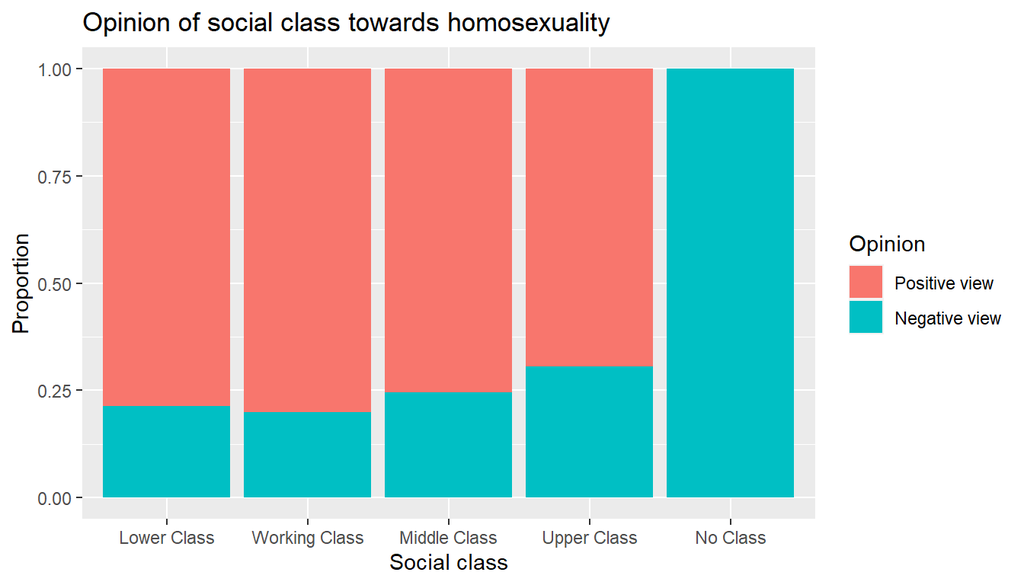

```r
#Visualization of data
g <- ggplot(all_time) + aes(x=class,fill=positive) + geom_bar(position = "fill") +
  labs(x="Social class",y="Proportion",title="Opinion of social class towards homosexuality") +
  scale_fill_discrete(name="Opinion",labels=c("Positive view","Negative view"))
g
```

```r
since_2006 <- filter(all_time,recent=="R")
summary(since_2006)
```

```
##       year                class                  homosex      positive
##  Min.   :2006   Lower Class  : 400   Always Wrong    :2809   Mode :logical
##  1st Qu.:2006   Working Class:2569   Almst Always Wrg: 228   FALSE:3438
##  Median :2008   Middle Class :2456   Sometimes Wrong : 401   TRUE :2167
##  Mean   :2009   Upper Class  : 180   Not Wrong At All:2167
##  3rd Qu.:2010   No Class     :   0   Other           :   0
##  Max.   :2012
##  recent
##  H:   0
##  R:5605
##
##
##
##
```

```r
since_2006_table <- table(since_2006$class,since_2006$positive)
since_2006_table
```

```
##
##                 FALSE TRUE
##   Lower Class     251  149
##   Working Class  1652  917
##   Middle Class   1438 1018
##   Upper Class      97   83
##   No Class          0    0
```

```r
prop.table(since_2006_table)
```

```
##
##                      FALSE       TRUE
##   Lower Class   0.04478145 0.02658341
##   Working Class 0.29473684 0.16360393
##   Middle Class  0.25655665 0.18162355
##   Upper Class   0.01730598 0.01480821
##   No Class      0.00000000 0.00000000
```

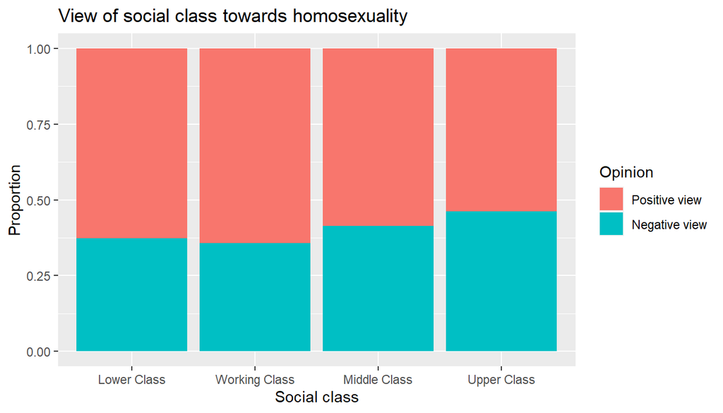

```r
#Visualization of data
h <- ggplot(since_2006) + aes(x=class,fill=positive) + geom_bar(position = "fill") +
  labs(x="Social class",y="Proportion",title="View of social class towards homosexuality") +
  scale_fill_discrete(name="Opinion",labels=c("Positive view","Negative view"))
h
```

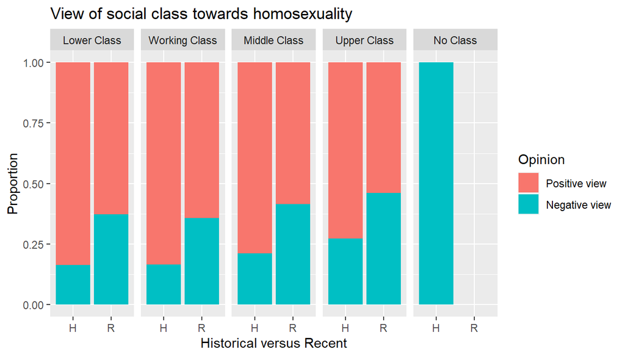

```r
 i<- ggplot(all_time) + aes(x=recent,fill=positive) + geom_bar(position = "fill") + facet_grid(.~class) +
  labs(x="Historical versus Recent",y="Proportion",title="View of social class towards homosexuality") +
  scale_fill_discrete(name="Opinion",labels=c("Positive view","Negative view"))
i
```

## Part 4: Inference

Hypotheses :  
H0 (Null hypothesis) : The respondent’s opinion towards homosexuality is independent of their social class.  
HA (Alternate hypothesis) : There is an association between respondent’s opinion towards homosexuality and their social class.

Method of Choice : Since the analysis involves 2 categorical variables (i.e social class and opinion towards homosexuality), chi-squared test for independence is opted which is used when comparing 2 categorical variables where one variable has more than 2 levels.

```r
str(all_time)
```

```
## 'data.frame':    31891 obs. of  5 variables:
##  $ year    : int  1973 1973 1973 1973 1973 1973 1973 1973 1973 1973 ...
##  $ class   : Factor w/ 5 levels "Lower Class",..: 2 3 2 3 2 2 2 2 3 2 ...
##  $ homosex : Factor w/ 5 levels "Always Wrong",..: 1 1 4 1 1 1 1 1 2 2 ...
##  $ positive: logi  FALSE FALSE TRUE FALSE FALSE FALSE ...
##  $ recent  : Factor w/ 2 levels "H","R": 1 1 1 1 1 1 1 1 1 1 ...
##  - attr(*, "na.action")= 'omit' Named int [1:25170] 1 2 3 4 5 6 7 8 9 10 ...
##   ..- attr(*, "names")= chr [1:25170] "1" "2" "3" "4" ...
```

```r
str(since_2006)
```

```
## 'data.frame':    5605 obs. of  5 variables:
##  $ year    : int  2006 2006 2006 2006 2006 2006 2006 2006 2006 2006 ...
##  $ class   : Factor w/ 5 levels "Lower Class",..: 2 2 3 2 3 3 1 2 2 2 ...
##  $ homosex : Factor w/ 5 levels "Always Wrong",..: 1 4 1 4 1 3 4 1 1 1 ...
##  $ positive: logi  FALSE TRUE FALSE TRUE FALSE FALSE ...
##  $ recent  : Factor w/ 2 levels "H","R": 2 2 2 2 2 2 2 2 2 2 ...
##  - attr(*, "na.action")= 'omit' Named int [1:25170] 1 2 3 4 5 6 7 8 9 10 ...
##   ..- attr(*, "names")= chr [1:25170] "1" "2" "3" "4" ...
```

Conditions :  
1. Independence between observations. This is unchanged as random sampling was implemented in GSS.  
2. As seen below, there are at least 5 counts for each cell except “no class” category.

```r
study_table1 <- table(all_time$class,all_time$positive)
study_table1
```

```
##
##                 FALSE  TRUE
##   Lower Class    1312   357
##   Working Class 11785  2942
##   Middle Class  10917  3560
##   Upper Class     706   311
##   No Class          0     1
```

```r
sum(study_table1<=5)
```

```
## [1] 2
```

So, we remove the row beloging to “no class” category.

```r
t1 <- study_table1[-5,]
t1
```

```
##
##                 FALSE  TRUE
##   Lower Class    1312   357
##   Working Class 11785  2942
##   Middle Class  10917  3560
##   Upper Class     706   311
```

```r
study_table2 <- table(since_2006$class,since_2006$positive)
study_table2
```

```
##
##                 FALSE TRUE
##   Lower Class     251  149
##   Working Class  1652  917
##   Middle Class   1438 1018
##   Upper Class      97   83
##   No Class          0    0
```

Now 2 cells have count < 5.

```r
sum(study_table2<=5)
```

```
## [1] 2
```

Again, removing the zero cells.

```r
t2 <- study_table2[-5,]
t2
```

```
##
##                 FALSE TRUE
##   Lower Class     251  149
##   Working Class  1652  917
##   Middle Class   1438 1018
##   Upper Class      97   83
```

Now, Chi-Squared test for independence was performed on both the data sets - the entire data set and the recent sub-set.

```r
c_all_time <- chisq.test(t1, all_time$class,all_time$positive)
c_all_time
```

```
##
##  Pearson's Chi-squared test
##
## data:  t1
## X-squared = 129.37, df = 3, p-value < 2.2e-16
```

```r
c_since_2006 <- chisq.test(t2, since_2006$class,since_2006$positive)
c_since_2006
```

```
##
##  Pearson's Chi-squared test
##
## data:  t2
## X-squared = 22.133, df = 3, p-value = 6.121e-05
```

As can be seen from the above results obtained, in both the cases, the null hypothesis was rejected and there is a significant association between social class and their opinion on homosexuality of respondents.  
Hence, we can infer that “Attitude towards homosexuality varies by social class”